# Dynamic regression models

2025-08-21

## Dynamic harmonic regression

### Advantages

- it allows any length seasonality;
- for data with more than one seasonal period, you can include Fourier terms of different frequencies;
- the seasonal pattern is smooth for small values of $K$ (but more wiggly seasonality can be handled by increasing $K$);
- the short-term dynamics are easily handled with a simple ARMA error.

### Disadvantages

- seasonality is assumed to be fixed (relatively small disadvantage)

## Eating-out expenditure

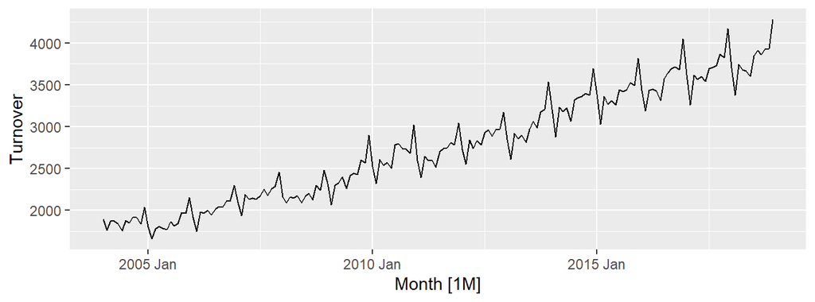

```r
aus_cafe <- aus_retail |>
  filter(Industry == "Cafes, restaurants and takeaway food services",
         year(Month) %in% 2004:2018) |>
  summarise(Turnover = sum(Turnover))
aus_cafe |> autoplot(Turnover)
```

Again we see an increase as the series progresses, and we use the log of the series to counter this.

## Eating-out expenditure

```r
fit <- aus_cafe |> model(
  `K = 1` = ARIMA(log(Turnover) ~ fourier(K = 1) + PDQ(0, 0, 0)),
  `K = 2` = ARIMA(log(Turnover) ~ fourier(K = 2) + PDQ(0, 0, 0)),
  `K = 3` = ARIMA(log(Turnover) ~ fourier(K = 3) + PDQ(0, 0, 0)),
  `K = 4` = ARIMA(log(Turnover) ~ fourier(K = 4) + PDQ(0, 0, 0)),
  `K = 5` = ARIMA(log(Turnover) ~ fourier(K = 5) + PDQ(0, 0, 0)),
  `K = 6` = ARIMA(log(Turnover) ~ fourier(K = 6) + PDQ(0, 0, 0)))
glance(fit)
```

We consider all possible fourier specifications, up to $K=6$. Interestingly, the lowest AICc is given by $K=6$.

| .model | sigma2 | log_lik | AIC | AICc | BIC |
| --- | --- | --- | --- | --- | --- |
| K = 1 | 0.0017471 | 317.2353 | -616.4707 | -615.4056 | -587.7842 |
| K = 2 | 0.0010732 | 361.8533 | -699.7066 | -697.8271 | -661.4579 |
| K = 3 | 0.0007609 | 393.6062 | -763.2125 | -761.3329 | -724.9638 |
| K = 4 | 0.0005386 | 426.7839 | -821.5678 | -818.2098 | -770.5697 |
| K = 5 | 0.0003173 | 473.7344 | -919.4688 | -916.9078 | -874.8454 |
| K = 6 | 0.0003163 | 474.0307 | -920.0614 | -917.5004 | -875.4380 |

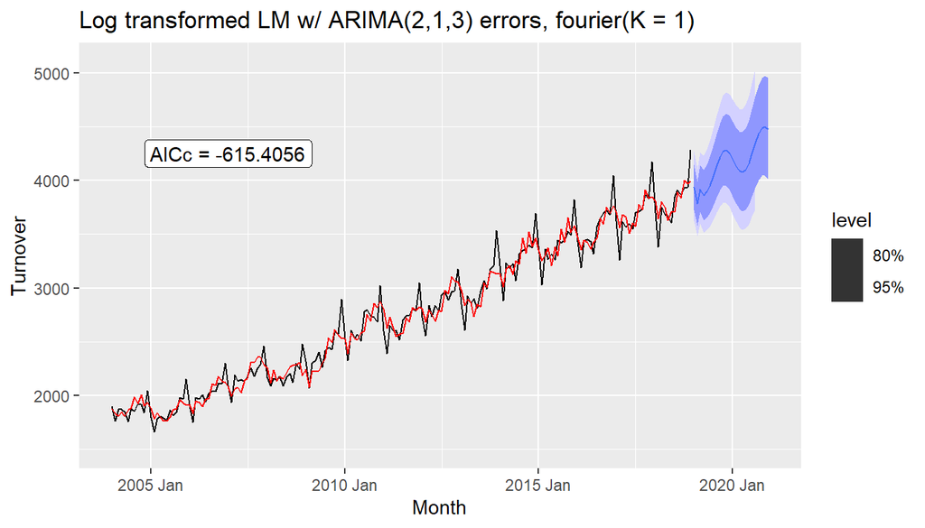

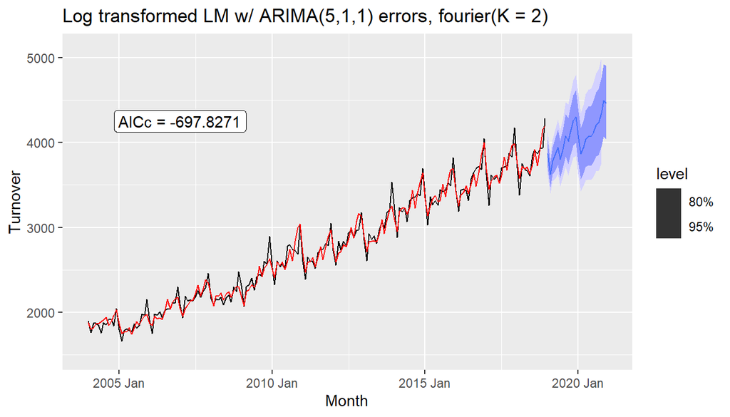

Notice that the ARIMA term gets simpler for larger values of $K$!

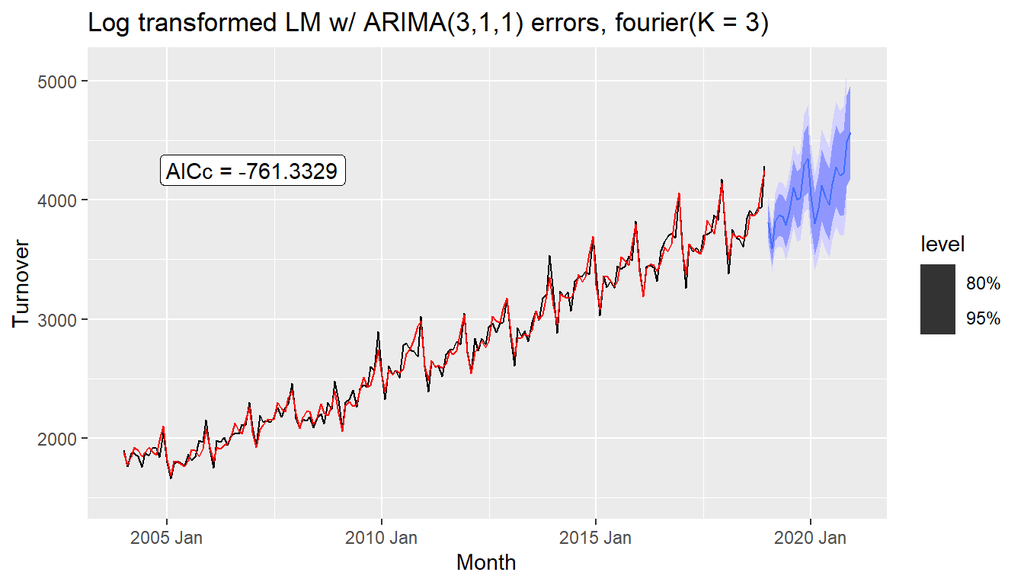

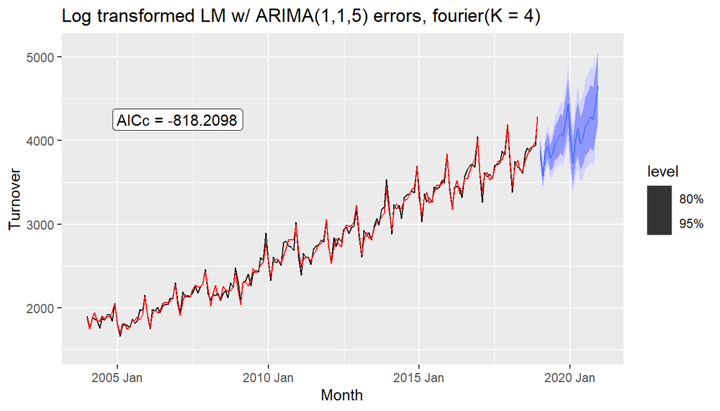

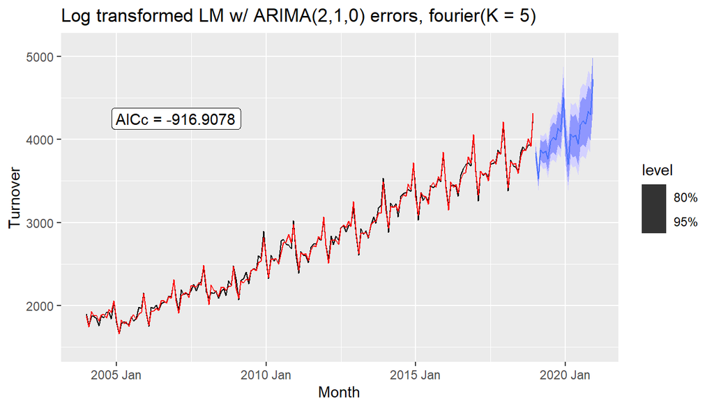

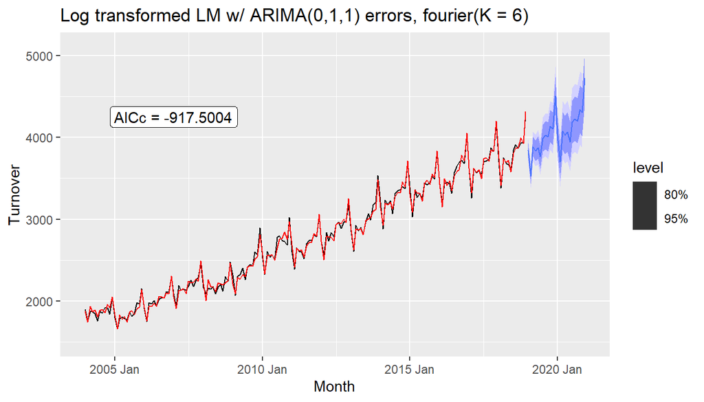

Note that here we have montly data, which can in fact easily be handled by a Seasonal ARIMA model. We now look at an example where Fourier terms help a lot: An example with with non-integer seasonality.

## Example: weekly gasoline products

After some trying around we set $K=6$:

```r
fit <- us_gasoline |>
  model(K06 = ARIMA(Barrels ~ fourier(K = 6) + PDQ(0, 0, 0)))
report(fit)
```

```
## Series: Barrels
## Model: LM w/ ARIMA(0,1,1) errors
##
## Coefficients:
##           ma1  fourier(K = 6)C1_52  fourier(K = 6)S1_52  fourier(K = 6)C2_52
##       -0.8956              -0.1122              -0.2300               0.0419
## s.e.   0.0130               0.0123               0.0122               0.0099
##       fourier(K = 6)S2_52  fourier(K = 6)C3_52  fourier(K = 6)S3_52
##                    0.0316               0.0832               0.0345
## s.e.               0.0099               0.0094               0.0094
##       fourier(K = 6)C4_52  fourier(K = 6)S4_52  fourier(K = 6)C5_52
##                    0.0186               0.0397              -0.0314
## s.e.               0.0093               0.0092               0.0092
##       fourier(K = 6)S5_52  fourier(K = 6)C6_52  fourier(K = 6)S6_52  intercept
##                    0.0010              -0.0522               0.0002     0.0014
## s.e.               0.0092               0.0091               0.0091     0.0007
##
## sigma^2 estimated as 0.06205:  log likelihood=-33.11
## AIC=96.23   AICc=96.59   BIC=174.39
```

## Example: weekly gasoline products

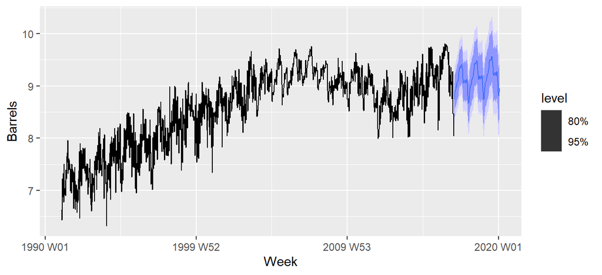

```r
forecast(fit, h = "3 years") |>
  autoplot(us_gasoline)
```

We have quite large prediction intervals, as there is a lot of noise in this dataset, but overall the prediction appears to make sense, which is quite impressive for a 3 year forecast of weekly data.